# Segmenting and Clustering Neighborhoods in Jakarta City

## Introduction

In this project, we are going to analyse the segmenting and clustering neighborhoods in Jakarta (Capital City of Indonesia). We are going to use ready data from [Biro Pusat Statistic](https://jakarta.bps.go.id/) (Statistics Indonesia), convert addresses into their equivalent latitude and longitude values. Also, we will use the [Foursquare API](https://foursquare.com/) to explore neighborhoods. We will use the **explore** function to get the most common venue categories in each neighborhood, and then use this feature to group the neighborhoods into clusters. We will use the *k*-means clustering algorithm to complete this task with Silhouette and Elbow Method to determine the number of clusters. We will use the Folium library to visualize the neighborhoods in Jakarta and their emerging clusters. Finally once each of neighbourhood is recognized, then we will propose the possible business to be done based on that Foursquare Venues. This infomation will be used by an investor to determine correct investment for each neighborhood in Jakarta.

1. Download and Explore Dataset 2. Explore Neighborhoods in Jakarta City 3. Analyze Each Neighborhood 4. Cluster Neighborhoods 5. Examine Clusters

Before we get the data and start exploring it, let's download all the dependencies that we will need.

```python
import numpy as np # library to handle data in a vectorized manner
import pandas as pd # library for data analsysis

pd.set_option('display.max_columns', None)
pd.set_option('display.max_rows', None)

import json # library to handle JSON files

#!conda install -c conda-forge geopy --yes # uncomment this line if you haven't completed the Foursquare API lab
from geopy.geocoders import Nominatim # convert an address into latitude and longitude values

import requests # library to handle requests
from pandas.io.json import json_normalize # tranform JSON file into a pandas dataframe
#from pandas.json_normalize import json_normalize


# Matplotlib and associated plotting modules
import matplotlib.cm as cm
import matplotlib.colors as colors

# import k-means from clustering stage
from sklearn.cluster import KMeans

#!conda install -c conda-forge folium=0.5.0 --yes # uncomment this line if you haven't completed the Foursquare API lab
import folium # map rendering library

print('Libraries imported.')
```

```
Libraries imported.
```

## 1. Download and Explore Dataset

**Tips**: We got the data from [BPS](https://www.jakarta.bps.go.id) and save it into file in server to avoid frequent access to Goverment website :)

```python
data = pd.read_csv("data-jumlah-kecamatan-2019.csv")
column_names = ['Kabupaten','Kecamatan','Luas']
data.columns = column_names
data.head()
```

|  | Kabupaten | Kecamatan | Luas |
| --- | --- | --- | --- |
| 0 | JAKARTA BARAT | CENGKARENG | 26.55 |
| 1 | JAKARTA BARAT | GROGOL PETAMBURAN | 9.99 |
| 2 | JAKARTA BARAT | KALI DERES | 30.23 |
| 3 | JAKARTA BARAT | KEBON JERUK | 17.63 |
| 4 | JAKARTA BARAT | KEMBANGAN | 24.17 |

Thanks to geolocator Nominatim we will get the equivalent of address

```python
geolocator = Nominatim(user_agent="ny_explorer")
coordinate = []

for index, row in data.iterrows():
    address = row['Kecamatan'] #+ ", " + row['Kabupaten']
    location = geolocator.geocode(address)
    if location is not None:
        coordinate.append([location.latitude, location.longitude])
    else:
        coordinate.append([null, null])


df_geo = pd.DataFrame(coordinate, columns=['Latitude', 'Longitude'])
neighborhoods=pd.merge(data, df_geo, left_index=True, right_index=True)
```

**Tips**: Geolocator tends to consume time, hence we store the data to avoid retrieving the data from internet for further references

```python
neighborhoods.to_csv(r'..\Coursera_Capstone\neighborhoods.csv')
```

```python
neighborhoods = pd.read_csv("neighborhoods.csv")
neighborhoods = neighborhoods.drop('Unnamed: 0', 1)
```

```python
neighborhoods.shape
```

```
(44, 5)
```

Quickly examine the resulting dataframe and we will have columns as below:

```python
neighborhoods.head()
```

|  | Kabupaten | Kecamatan | Luas | Latitude | Longitude |
| --- | --- | --- | --- | --- | --- |
| 0 | JAKARTA BARAT | CENGKARENG | 26.55 | -6.149093 | 106.734781 |
| 1 | JAKARTA BARAT | GROGOL PETAMBURAN | 9.99 | -6.164188 | 106.788317 |
| 2 | JAKARTA BARAT | KALI DERES | 30.23 | -6.134300 | 106.705800 |
| 3 | JAKARTA BARAT | KEBON JERUK | 17.63 | -6.192572 | 106.769725 |
| 4 | JAKARTA BARAT | KEMBANGAN | 24.17 | -6.193000 | 106.742600 |

```python
print('As mentioned in the introduction The dataframe has {} Kabupaten and {} Kecamatan.'.format(
        len(neighborhoods['Kabupaten'].unique()),
        neighborhoods.shape[0]
    )
)
```

```
As mentioned in the introduction The dataframe has 6 Kabupaten and 44 Kecamatan.
```

#### Use geopy library to get the latitude and longitude values of Jakarta.

In order to define an instance of the geocoder, we need to define a user_agent. We will name our agent *ny_explorer*, as shown below.

```python
address = 'Jakarta'

geolocator = Nominatim(user_agent="ny_explorer")
location = geolocator.geocode(address)
latitude = location.latitude
longitude = location.longitude
print('The geograpical coordinate of Jakarta are {}, {}.'.format(latitude, longitude))
```

```
The geograpical coordinate of Jakarta are -6.1753942, 106.827183.
```

#### Create a map of Jakarta with neighborhoods superimposed on top.

```python
# create map of New York using latitude and longitude values
map_Jakarta = folium.Map(location=[latitude, longitude], zoom_start=10)

# add markers to map
for lat, lng, borough, neighborhood in zip(neighborhoods['Latitude'], neighborhoods['Longitude'], neighborhoods['Kabupaten'], neighborhoods['Kecamatan']):
    label = '{}, {}'.format(neighborhood, borough)
    label = folium.Popup(label, parse_html=True)
    folium.CircleMarker(
        [lat, lng],
        radius=5,
        popup=label,
        color='blue',
        fill=True,
        fill_color='#3186cc',
        fill_opacity=0.7,
        parse_html=False).add_to(map_Jakarta)

map_Jakarta
```

Make this Notebook Trusted to load map: File -> Trust Notebook

[interactive chart not shown]

**Folium** is a great visualization library. Feel free to zoom into the above map, and click on each circle mark to reveal the name of Kecamatan and respective Kabupaten

Next, we are going to start utilizing the Foursquare API to explore the neighborhoods and segment them.

#### Define Foursquare Credentials and Version

```python
CLIENT_ID = 'WAFDIUY5OL25UM44YNMRQWZNT5OQ2CVL0RJD4QE4IHFJYS4R' # your Foursquare ID
CLIENT_SECRET = 'X044CFGQSJCIGKLPD2XNZREII0FISRGRZ0CIQQKDRSLQ0BSS' # your Foursquare Secret
VERSION = '20180605' # Foursquare API version

#CLIENT_ID = 'your-client-ID' # your Foursquare ID
#CLIENT_SECRET = 'your-client-secret' # your Foursquare Secret
#VERSION = '20180605' # Foursquare API version
LIMIT = 100 # A default Foursquare API limit value

print('Your credentails:')
print('CLIENT_ID: ' + CLIENT_ID)
print('CLIENT_SECRET:' + CLIENT_SECRET)
```

```
Your credentails:
CLIENT_ID: WAFDIUY5OL25UM44YNMRQWZNT5OQ2CVL0RJD4QE4IHFJYS4R
CLIENT_SECRET:X044CFGQSJCIGKLPD2XNZREII0FISRGRZ0CIQQKDRSLQ0BSS
```

#### Let's explore the first Kecamatan in our dataframe.

Let's try and get the Kecamatan's name.

```python
jakarta_data=neighborhoods.reset_index(drop=True)
```

```python
print('Get latitude and longitude values of Kecamatan {}.'.format(jakarta_data.loc[0, 'Kecamatan']))
```

```
Get latitude and longitude values of Kecamatan CENGKARENG.
```

```python
neighborhood_latitude = jakarta_data.loc[0, 'Latitude'] # neighborhood latitude value
neighborhood_longitude = jakarta_data.loc[0, 'Longitude'] # neighborhood longitude value

neighborhood_name = jakarta_data.loc[0, 'Kecamatan'] # neighborhood name

print('Latitude and longitude values of {} are {}, {}.'.format(neighborhood_name,
                                                               neighborhood_latitude,
                                                               neighborhood_longitude))
```

```
Latitude and longitude values of CENGKARENG are -6.1490933, 106.73478100000001.
```

#### Now, let's get the top 100 venues that are within a radius of 500 meters.

First, let's create the GET request URL. Name your URL **url**.

```python
# type your answer here
LIMIT = 100 # limit of number of venues returned by Foursquare API


radius = 500 # define radius


 # create URL
url = 'https://api.foursquare.com/v2/venues/explore?&client_id={}&client_secret={}&v={}&ll={},{}&radius={}&limit={}'.format(
    CLIENT_ID,
    CLIENT_SECRET,
    VERSION,
    neighborhood_latitude,
    neighborhood_longitude,
    radius,
    LIMIT)
url # display URL
```

```
'https://api.foursquare.com/v2/venues/explore?&client_id=WAFDIUY5OL25UM44YNMRQWZNT5OQ2CVL0RJD4QE4IHFJYS4R&client_secret=X044CFGQSJCIGKLPD2XNZREII0FISRGRZ0CIQQKDRSLQ0BSS&v=20180605&ll=-6.1490933,106.73478100000001&radius=500&limit=100'
```

Send the GET request and examine the resutls

```python
results = requests.get(url).json()
results
```

[output not shown]

[output cut: 121 more lines]

[output not shown]

From the Foursquare lab in the previous module, we know that all the information is in the *items* key. Before we proceed, let's borrow the **get_category_type** function from the Foursquare lab.

```python
# function that extracts the category of the venue
def get_category_type(row):
    try:
        categories_list = row['categories']
    except:
        categories_list = row['venue.categories']

    if len(categories_list) == 0:
        return None
    else:
        return categories_list[0]['name']
```

Now we are ready to clean the json and structure it into a *pandas* dataframe.

```python
venues = results['response']['groups'][0]['items']

nearby_venues = pd.json_normalize(venues) # flatten JSON

# filter columns
filtered_columns = ['venue.name', 'venue.categories', 'venue.location.lat', 'venue.location.lng']
nearby_venues =nearby_venues.loc[:, filtered_columns]

# filter the category for each row
nearby_venues['venue.categories'] = nearby_venues.apply(get_category_type, axis=1)

# clean columns
nearby_venues.columns = [col.split(".")[-1] for col in nearby_venues.columns]

nearby_venues.head()
```

|  | name | categories | lat | lng |
| --- | --- | --- | --- | --- |
| 0 | XXI Puri Indah Mall | Movie Theater | -6.151018 | 106.733983 |
| 1 | Studio 29 | Music Venue | -6.146643 | 106.732274 |
| 2 | Laut Dadap | Harbor / Marina | -6.148722 | 106.732940 |
| 3 | Family Mart City Park Apartement | Night Market | -6.146726 | 106.735641 |
| 4 | Mie Baso | Restaurant | -6.149799 | 106.730642 |

And how many venues were returned by Foursquare?

```python
print('{} venues were returned by Foursquare.'.format(nearby_venues.shape[0]))
```

```
6 venues were returned by Foursquare.
```

## 2. Explore Neighborhoods in Jakarta

#### Let's create a function to repeat the same process to all the neighborhoods in Jakarta

```python
def getNearbyVenues(names, latitudes, longitudes, radius=500):

    venues_list=[]
    for name, lat, lng in zip(names, latitudes, longitudes):
        print(name)

        # create the API request URL
        url = 'https://api.foursquare.com/v2/venues/explore?&client_id={}&client_secret={}&v={}&ll={},{}&radius={}&limit={}'.format(
            CLIENT_ID,
            CLIENT_SECRET,
            VERSION,
            lat,
            lng,
            radius,
            LIMIT)

        # make the GET request
        results = requests.get(url).json()["response"]['groups'][0]['items']

        # return only relevant information for each nearby venue
        venues_list.append([(
            name,
            lat,
            lng,
            v['venue']['name'],
            v['venue']['location']['lat'],
            v['venue']['location']['lng'],
            v['venue']['categories'][0]['name']) for v in results])

    nearby_venues = pd.DataFrame([item for venue_list in venues_list for item in venue_list])
    nearby_venues.columns = ['Kecamatan',
                  'Kecamatan Latitude',
                  'Kecamatan Longitude',
                  'Venue',
                  'Venue Latitude',
                  'Venue Longitude',
                  'Venue Category']

    return(nearby_venues)
```

```python
jakarta_venues = getNearbyVenues(names=jakarta_data['Kecamatan'],
                                   latitudes=jakarta_data['Latitude'],
                                   longitudes=jakarta_data['Longitude']
                                  )
```

```
CENGKARENG
GROGOL PETAMBURAN
KALI DERES
KEBON JERUK
KEMBANGAN
PALMERAH
TAMAN SARI
TAMBORA
CEMPAKA PUTIH
GAMBIR
JOHAR BARU
KEMAYORAN
MENTENG
SAWAH BESAR
SENEN
TANAH ABANG
CILANDAK
JAGAKARSA
KEBAYORAN BARU
KEBAYORAN LAMA
MAMPANG PRAPATAN
PANCORAN
PASAR MINGGU
PESANGGRAHAN
SETIA BUDI
TEBET
CAKUNG
CIPAYUNG
CIRACAS
DUREN SAWIT
JATINEGARA
KRAMAT JATI
MAKASAR
MATRAMAN
PASAR REBO
PULO GADUNG
CILINCING
KELAPA GADING
KOJA
PADEMANGAN
PENJARINGAN
TANJUNG PRIOK
KEPULAUAN SERIBU SELATAN
KEPULAUAN SERIBU UTARA
```

#### Let's check the size of the resulting dataframe

```python
print(jakarta_venues.shape)
jakarta_venues.head()
```

```
(719, 7)
```

|  | Kecamatan | Kecamatan Latitude | Kecamatan Longitude | Venue | Venue Latitude | Venue Longitude | Venue Category |
| --- | --- | --- | --- | --- | --- | --- | --- |
| 0 | CENGKARENG | -6.149093 | 106.734781 | XXI Puri Indah Mall | -6.151018 | 106.733983 | Movie Theater |
| 1 | CENGKARENG | -6.149093 | 106.734781 | Studio 29 | -6.146643 | 106.732274 | Music Venue |
| 2 | CENGKARENG | -6.149093 | 106.734781 | Laut Dadap | -6.148722 | 106.732940 | Harbor / Marina |
| 3 | CENGKARENG | -6.149093 | 106.734781 | Family Mart City Park Apartement | -6.146726 | 106.735641 | Night Market |
| 4 | CENGKARENG | -6.149093 | 106.734781 | Mie Baso | -6.149799 | 106.730642 | Restaurant |

**Tips**: To avoid frequent access to Foursquare API since we only use Developer Free License, then we store the data into file locally

```python
jakarta_venues.to_csv(r'..\Coursera_Capstone\jakarta_venues.csv')
```

```python
#to import from file
jakarta_venues = pd.read_csv("jakarta_venues.csv")
jakarta_venues = jakarta_venues.drop('Unnamed: 0', 1)
```

Let's check how many venues were returned for each Kecamatan

```python
jakarta_venues.groupby('Kecamatan').count()
```

| Kecamatan | Kecamatan Latitude | Kecamatan Longitude | Venue | Venue Latitude | Venue Longitude | Venue Category |
| --- | --- | --- | --- | --- | --- | --- |
| CAKUNG | 3 | 3 | 3 | 3 | 3 | 3 |
| CEMPAKA PUTIH | 7 | 7 | 7 | 7 | 7 | 7 |
| CENGKARENG | 6 | 6 | 6 | 6 | 6 | 6 |
| CILANDAK | 21 | 21 | 21 | 21 | 21 | 21 |
| CILINCING | 2 | 2 | 2 | 2 | 2 | 2 |
| CIPAYUNG | 2 | 2 | 2 | 2 | 2 | 2 |
| CIRACAS | 2 | 2 | 2 | 2 | 2 | 2 |
| DUREN SAWIT | 5 | 5 | 5 | 5 | 5 | 5 |
| GAMBIR | 15 | 15 | 15 | 15 | 15 | 15 |
| GROGOL PETAMBURAN | 35 | 35 | 35 | 35 | 35 | 35 |
| JAGAKARSA | 13 | 13 | 13 | 13 | 13 | 13 |
| JATINEGARA | 16 | 16 | 16 | 16 | 16 | 16 |
| JOHAR BARU | 4 | 4 | 4 | 4 | 4 | 4 |
| KALI DERES | 8 | 8 | 8 | 8 | 8 | 8 |
| KEBAYORAN BARU | 33 | 33 | 33 | 33 | 33 | 33 |
| KEBAYORAN LAMA | 84 | 84 | 84 | 84 | 84 | 84 |
| KEBON JERUK | 23 | 23 | 23 | 23 | 23 | 23 |
| KELAPA GADING | 21 | 21 | 21 | 21 | 21 | 21 |
| KEMAYORAN | 4 | 4 | 4 | 4 | 4 | 4 |
| KEMBANGAN | 14 | 14 | 14 | 14 | 14 | 14 |
| KEPULAUAN SERIBU SELATAN | 2 | 2 | 2 | 2 | 2 | 2 |
| KEPULAUAN SERIBU UTARA | 1 | 1 | 1 | 1 | 1 | 1 |
| KOJA | 4 | 4 | 4 | 4 | 4 | 4 |
| KRAMAT JATI | 4 | 4 | 4 | 4 | 4 | 4 |
| MAKASAR | 4 | 4 | 4 | 4 | 4 | 4 |
| MAMPANG PRAPATAN | 5 | 5 | 5 | 5 | 5 | 5 |
| MATRAMAN | 5 | 5 | 5 | 5 | 5 | 5 |
| MENTENG | 29 | 29 | 29 | 29 | 29 | 29 |
| PADEMANGAN | 13 | 13 | 13 | 13 | 13 | 13 |
| PALMERAH | 16 | 16 | 16 | 16 | 16 | 16 |
| PANCORAN | 16 | 16 | 16 | 16 | 16 | 16 |
| PASAR MINGGU | 11 | 11 | 11 | 11 | 11 | 11 |
| PASAR REBO | 4 | 4 | 4 | 4 | 4 | 4 |
| PENJARINGAN | 4 | 4 | 4 | 4 | 4 | 4 |
| PESANGGRAHAN | 5 | 5 | 5 | 5 | 5 | 5 |
| PULO GADUNG | 33 | 33 | 33 | 33 | 33 | 33 |
| SAWAH BESAR | 19 | 19 | 19 | 19 | 19 | 19 |
| SENEN | 14 | 14 | 14 | 14 | 14 | 14 |
| SETIA BUDI | 43 | 43 | 43 | 43 | 43 | 43 |
| TAMAN SARI | 76 | 76 | 76 | 76 | 76 | 76 |
| TAMBORA | 9 | 9 | 9 | 9 | 9 | 9 |
| TANAH ABANG | 18 | 18 | 18 | 18 | 18 | 18 |
| TANJUNG PRIOK | 3 | 3 | 3 | 3 | 3 | 3 |
| TEBET | 63 | 63 | 63 | 63 | 63 | 63 |

#### Let's find out how many unique categories can be curated from all the returned venues

```python
print('There are {} uniques categories.'.format(len(jakarta_venues['Venue Category'].unique())))
```

```
There are 156 uniques categories.
```

## 3. Analyze Each Kecamatan

```python
# one hot encoding
jakarta_onehot = pd.get_dummies(jakarta_venues[['Venue Category']], prefix="", prefix_sep="")

# add neighborhood column back to dataframe
jakarta_onehot['Kecamatan'] = jakarta_venues['Kecamatan']

# move neighborhood column to the first column
fixed_columns = [jakarta_onehot.columns[-1]] + list(jakarta_onehot.columns[:-1])
jakarta_onehot = jakarta_onehot[fixed_columns]

jakarta_onehot.head()
```

|  | Kecamatan | Accessories Store | Acehnese Restaurant | Airport Lounge | American Restaurant | Arcade | Art Gallery | Art Museum | Arts & Crafts Store | Asian Restaurant | Athletics & Sports | Auto Dealership | Automotive Shop | BBQ Joint | Bakery | Balinese Restaurant | Bar | Basketball Court | Basketball Stadium | Bed & Breakfast | Boat or Ferry | Bookstore | Boutique | Bowling Alley | Breakfast Spot | Bubble Tea Shop | Buffet | Building | Burger Joint | … |
| --- | --- | --- | --- | --- | --- | --- | --- | --- | --- | --- | --- | --- | --- | --- | --- | --- | --- | --- | --- | --- | --- | --- | --- | --- | --- | --- | --- | --- | --- | --- |
| 0 | CENGKARENG | 0 | 0 | 0 | 0 | 0 | 0 | 0 | 0 | 0 | 0 | 0 | 0 | 0 | 0 | 0 | 0 | 0 | 0 | 0 | 0 | 0 | 0 | 0 | 0 | 0 | 0 | 0 | 0 | … |
| 1 | CENGKARENG | 0 | 0 | 0 | 0 | 0 | 0 | 0 | 0 | 0 | 0 | 0 | 0 | 0 | 0 | 0 | 0 | 0 | 0 | 0 | 0 | 0 | 0 | 0 | 0 | 0 | 0 | 0 | 0 | … |
| 2 | CENGKARENG | 0 | 0 | 0 | 0 | 0 | 0 | 0 | 0 | 0 | 0 | 0 | 0 | 0 | 0 | 0 | 0 | 0 | 0 | 0 | 0 | 0 | 0 | 0 | 0 | 0 | 0 | 0 | 0 | … |
| 3 | CENGKARENG | 0 | 0 | 0 | 0 | 0 | 0 | 0 | 0 | 0 | 0 | 0 | 0 | 0 | 0 | 0 | 0 | 0 | 0 | 0 | 0 | 0 | 0 | 0 | 0 | 0 | 0 | 0 | 0 | … |
| 4 | CENGKARENG | 0 | 0 | 0 | 0 | 0 | 0 | 0 | 0 | 0 | 0 | 0 | 0 | 0 | 0 | 0 | 0 | 0 | 0 | 0 | 0 | 0 | 0 | 0 | 0 | 0 | 0 | 0 | 0 | … |

And let's examine the new dataframe size.

```python
jakarta_onehot.shape
```

```
(719, 157)
```

#### Next, let's group rows by Kecamatan and by taking the mean of the frequency of occurrence of each category

```python
jakarta_grouped = jakarta_onehot.groupby('Kecamatan').mean().reset_index()
jakarta_grouped
```

|  | Kecamatan | Accessories Store | Acehnese Restaurant | Airport Lounge | American Restaurant | Arcade | Art Gallery | Art Museum | Arts & Crafts Store | Asian Restaurant | Athletics & Sports | Auto Dealership | Automotive Shop | BBQ Joint | Bakery | Balinese Restaurant | Bar | Basketball Court | Basketball Stadium | Bed & Breakfast | Boat or Ferry | Bookstore | Boutique | Bowling Alley | Breakfast Spot | Bubble Tea Shop | Buffet | Building | Burger Joint | … |
| --- | --- | --- | --- | --- | --- | --- | --- | --- | --- | --- | --- | --- | --- | --- | --- | --- | --- | --- | --- | --- | --- | --- | --- | --- | --- | --- | --- | --- | --- | --- |
| 0 | CAKUNG | 0.000000 | 0.000000 | 0.00 | 0.000000 | 0.000000 | 0.000000 | 0.000000 | 0.0000 | 0.000000 | 0.000000 | 0.000000 | 0.000000 | 0.000000 | 0.000000 | 0.000000 | 0.000000 | 0.000000 | 0.000000 | 0.000000 | 0.0 | 0.000000 | 0.000000 | 0.000000 | 0.000000 | 0.000000 | 0.000000 | 0.000000 | 0.000000 | … |
| 1 | CEMPAKA PUTIH | 0.000000 | 0.142857 | 0.00 | 0.000000 | 0.000000 | 0.000000 | 0.000000 | 0.0000 | 0.000000 | 0.000000 | 0.000000 | 0.000000 | 0.142857 | 0.000000 | 0.000000 | 0.000000 | 0.000000 | 0.000000 | 0.000000 | 0.0 | 0.000000 | 0.000000 | 0.000000 | 0.000000 | 0.000000 | 0.000000 | 0.000000 | 0.000000 | … |
| 2 | CENGKARENG | 0.000000 | 0.000000 | 0.00 | 0.000000 | 0.000000 | 0.000000 | 0.000000 | 0.0000 | 0.000000 | 0.000000 | 0.000000 | 0.000000 | 0.000000 | 0.000000 | 0.000000 | 0.000000 | 0.000000 | 0.000000 | 0.000000 | 0.0 | 0.000000 | 0.000000 | 0.000000 | 0.000000 | 0.000000 | 0.000000 | 0.000000 | 0.000000 | … |
| 3 | CILANDAK | 0.000000 | 0.000000 | 0.00 | 0.000000 | 0.000000 | 0.000000 | 0.000000 | 0.0000 | 0.047619 | 0.000000 | 0.000000 | 0.000000 | 0.000000 | 0.000000 | 0.000000 | 0.000000 | 0.000000 | 0.000000 | 0.000000 | 0.0 | 0.047619 | 0.000000 | 0.000000 | 0.000000 | 0.000000 | 0.000000 | 0.000000 | 0.000000 | … |
| 4 | CILINCING | 0.000000 | 0.000000 | 0.00 | 0.000000 | 0.000000 | 0.000000 | 0.000000 | 0.0000 | 0.000000 | 0.000000 | 0.000000 | 0.000000 | 0.000000 | 0.000000 | 0.000000 | 0.000000 | 0.000000 | 0.000000 | 0.000000 | 0.0 | 0.000000 | 0.000000 | 0.000000 | 0.000000 | 0.000000 | 0.000000 | 0.000000 | 0.000000 | … |
| 5 | CIPAYUNG | 0.000000 | 0.000000 | 0.00 | 0.000000 | 0.000000 | 0.000000 | 0.000000 | 0.0000 | 0.000000 | 0.000000 | 0.000000 | 0.000000 | 0.000000 | 0.000000 | 0.000000 | 0.000000 | 0.000000 | 0.000000 | 0.000000 | 0.0 | 0.000000 | 0.000000 | 0.000000 | 0.000000 | 0.000000 | 0.000000 | 0.000000 | 0.000000 | … |
| 6 | CIRACAS | 0.000000 | 0.000000 | 0.00 | 0.000000 | 0.000000 | 0.000000 | 0.000000 | 0.0000 | 0.000000 | 0.000000 | 0.000000 | 0.000000 | 0.000000 | 0.000000 | 0.000000 | 0.000000 | 0.000000 | 0.000000 | 0.000000 | 0.0 | 0.000000 | 0.000000 | 0.000000 | 0.000000 | 0.000000 | 0.000000 | 0.000000 | 0.000000 | … |
| 7 | DUREN SAWIT | 0.000000 | 0.000000 | 0.00 | 0.000000 | 0.000000 | 0.000000 | 0.000000 | 0.0000 | 0.000000 | 0.000000 | 0.000000 | 0.000000 | 0.000000 | 0.000000 | 0.000000 | 0.000000 | 0.000000 | 0.000000 | 0.000000 | 0.0 | 0.000000 | 0.000000 | 0.000000 | 0.000000 | 0.000000 | 0.000000 | 0.000000 | 0.000000 | … |
| 8 | GAMBIR | 0.000000 | 0.000000 | 0.00 | 0.000000 | 0.000000 | 0.000000 | 0.000000 | 0.0000 | 0.000000 | 0.000000 | 0.000000 | 0.000000 | 0.000000 | 0.066667 | 0.000000 | 0.000000 | 0.000000 | 0.000000 | 0.000000 | 0.0 | 0.000000 | 0.000000 | 0.000000 | 0.000000 | 0.000000 | 0.000000 | 0.000000 | 0.000000 | … |
| 9 | GROGOL PETAMBURAN | 0.000000 | 0.000000 | 0.00 | 0.000000 | 0.000000 | 0.000000 | 0.000000 | 0.0000 | 0.114286 | 0.000000 | 0.000000 | 0.000000 | 0.000000 | 0.000000 | 0.000000 | 0.000000 | 0.000000 | 0.000000 | 0.000000 | 0.0 | 0.028571 | 0.000000 | 0.000000 | 0.000000 | 0.000000 | 0.000000 | 0.000000 | 0.000000 | … |
| 10 | JAGAKARSA | 0.000000 | 0.000000 | 0.00 | 0.000000 | 0.076923 | 0.000000 | 0.000000 | 0.0000 | 0.153846 | 0.000000 | 0.000000 | 0.000000 | 0.076923 | 0.000000 | 0.000000 | 0.000000 | 0.000000 | 0.000000 | 0.000000 | 0.0 | 0.000000 | 0.000000 | 0.000000 | 0.000000 | 0.000000 | 0.000000 | 0.000000 | 0.000000 | … |
| 11 | JATINEGARA | 0.000000 | 0.000000 | 0.00 | 0.000000 | 0.000000 | 0.000000 | 0.000000 | 0.0625 | 0.187500 | 0.000000 | 0.000000 | 0.000000 | 0.000000 | 0.000000 | 0.000000 | 0.000000 | 0.000000 | 0.000000 | 0.000000 | 0.0 | 0.000000 | 0.000000 | 0.000000 | 0.000000 | 0.000000 | 0.000000 | 0.000000 | 0.000000 | … |
| 12 | JOHAR BARU | 0.000000 | 0.000000 | 0.00 | 0.000000 | 0.250000 | 0.000000 | 0.000000 | 0.0000 | 0.000000 | 0.000000 | 0.000000 | 0.000000 | 0.000000 | 0.000000 | 0.000000 | 0.000000 | 0.000000 | 0.000000 | 0.000000 | 0.0 | 0.000000 | 0.000000 | 0.000000 | 0.000000 | 0.000000 | 0.000000 | 0.000000 | 0.000000 | … |
| 13 | KALI DERES | 0.000000 | 0.000000 | 0.00 | 0.000000 | 0.000000 | 0.000000 | 0.000000 | 0.0000 | 0.000000 | 0.000000 | 0.000000 | 0.000000 | 0.000000 | 0.000000 | 0.000000 | 0.000000 | 0.000000 | 0.000000 | 0.000000 | 0.0 | 0.000000 | 0.000000 | 0.000000 | 0.000000 | 0.000000 | 0.000000 | 0.000000 | 0.000000 | … |
| 14 | KEBAYORAN BARU | 0.000000 | 0.000000 | 0.00 | 0.000000 | 0.000000 | 0.000000 | 0.000000 | 0.0000 | 0.000000 | 0.000000 | 0.000000 | 0.000000 | 0.000000 | 0.000000 | 0.000000 | 0.000000 | 0.000000 | 0.000000 | 0.000000 | 0.0 | 0.000000 | 0.000000 | 0.000000 | 0.000000 | 0.030303 | 0.000000 | 0.000000 | 0.030303 | … |
| 15 | KEBAYORAN LAMA | 0.000000 | 0.000000 | 0.00 | 0.011905 | 0.011905 | 0.011905 | 0.000000 | 0.0000 | 0.011905 | 0.000000 | 0.000000 | 0.000000 | 0.011905 | 0.047619 | 0.000000 | 0.000000 | 0.000000 | 0.000000 | 0.000000 | 0.0 | 0.011905 | 0.000000 | 0.000000 | 0.000000 | 0.023810 | 0.011905 | 0.000000 | 0.000000 | … |
| 16 | KEBON JERUK | 0.000000 | 0.000000 | 0.00 | 0.000000 | 0.043478 | 0.000000 | 0.043478 | 0.0000 | 0.086957 | 0.000000 | 0.043478 | 0.000000 | 0.000000 | 0.043478 | 0.000000 | 0.000000 | 0.000000 | 0.000000 | 0.000000 | 0.0 | 0.000000 | 0.000000 | 0.000000 | 0.000000 | 0.000000 | 0.000000 | 0.000000 | 0.000000 | … |
| 17 | KELAPA GADING | 0.000000 | 0.000000 | 0.00 | 0.000000 | 0.000000 | 0.000000 | 0.000000 | 0.0000 | 0.142857 | 0.000000 | 0.000000 | 0.000000 | 0.000000 | 0.000000 | 0.000000 | 0.000000 | 0.000000 | 0.000000 | 0.000000 | 0.0 | 0.000000 | 0.000000 | 0.000000 | 0.000000 | 0.000000 | 0.000000 | 0.000000 | 0.000000 | … |
| 18 | KEMAYORAN | 0.000000 | 0.000000 | 0.00 | 0.000000 | 0.250000 | 0.000000 | 0.000000 | 0.0000 | 0.000000 | 0.000000 | 0.000000 | 0.000000 | 0.000000 | 0.000000 | 0.000000 | 0.000000 | 0.000000 | 0.000000 | 0.000000 | 0.0 | 0.000000 | 0.000000 | 0.000000 | 0.000000 | 0.000000 | 0.000000 | 0.000000 | 0.000000 | … |
| 19 | KEMBANGAN | 0.000000 | 0.000000 | 0.00 | 0.000000 | 0.000000 | 0.000000 | 0.000000 | 0.0000 | 0.214286 | 0.000000 | 0.000000 | 0.000000 | 0.000000 | 0.000000 | 0.000000 | 0.000000 | 0.000000 | 0.000000 | 0.000000 | 0.0 | 0.000000 | 0.000000 | 0.000000 | 0.000000 | 0.071429 | 0.000000 | 0.000000 | 0.000000 | … |
| 20 | KEPULAUAN SERIBU SELATAN | 0.000000 | 0.000000 | 0.00 | 0.000000 | 0.000000 | 0.000000 | 0.000000 | 0.0000 | 0.000000 | 0.000000 | 0.000000 | 0.000000 | 0.000000 | 0.000000 | 0.000000 | 0.000000 | 0.000000 | 0.000000 | 0.000000 | 0.5 | 0.000000 | 0.000000 | 0.000000 | 0.000000 | 0.000000 | 0.000000 | 0.000000 | 0.000000 | … |
| 21 | KEPULAUAN SERIBU UTARA | 0.000000 | 0.000000 | 0.00 | 0.000000 | 0.000000 | 0.000000 | 0.000000 | 0.0000 | 0.000000 | 0.000000 | 0.000000 | 0.000000 | 0.000000 | 0.000000 | 0.000000 | 0.000000 | 0.000000 | 0.000000 | 0.000000 | 0.0 | 0.000000 | 0.000000 | 0.000000 | 0.000000 | 0.000000 | 0.000000 | 0.000000 | 0.000000 | … |
| 22 | KOJA | 0.000000 | 0.000000 | 0.00 | 0.000000 | 0.000000 | 0.000000 | 0.000000 | 0.0000 | 0.000000 | 0.000000 | 0.000000 | 0.000000 | 0.000000 | 0.000000 | 0.000000 | 0.000000 | 0.000000 | 0.000000 | 0.000000 | 0.0 | 0.250000 | 0.000000 | 0.000000 | 0.000000 | 0.000000 | 0.000000 | 0.000000 | 0.000000 | … |
| 23 | KRAMAT JATI | 0.000000 | 0.000000 | 0.00 | 0.000000 | 0.000000 | 0.000000 | 0.000000 | 0.0000 | 0.000000 | 0.000000 | 0.000000 | 0.000000 | 0.000000 | 0.000000 | 0.000000 | 0.000000 | 0.000000 | 0.000000 | 0.000000 | 0.0 | 0.000000 | 0.000000 | 0.000000 | 0.000000 | 0.000000 | 0.000000 | 0.000000 | 0.000000 | … |
| 24 | MAKASAR | 0.000000 | 0.000000 | 0.25 | 0.000000 | 0.000000 | 0.000000 | 0.000000 | 0.0000 | 0.250000 | 0.000000 | 0.000000 | 0.000000 | 0.000000 | 0.000000 | 0.000000 | 0.000000 | 0.000000 | 0.000000 | 0.000000 | 0.0 | 0.000000 | 0.000000 | 0.000000 | 0.000000 | 0.000000 | 0.000000 | 0.000000 | 0.000000 | … |
| 25 | MAMPANG PRAPATAN | 0.000000 | 0.000000 | 0.00 | 0.000000 | 0.000000 | 0.000000 | 0.000000 | 0.0000 | 0.000000 | 0.000000 | 0.000000 | 0.000000 | 0.000000 | 0.000000 | 0.000000 | 0.000000 | 0.000000 | 0.000000 | 0.000000 | 0.0 | 0.000000 | 0.000000 | 0.000000 | 0.000000 | 0.000000 | 0.000000 | 0.000000 | 0.000000 | … |
| 26 | MATRAMAN | 0.000000 | 0.000000 | 0.00 | 0.000000 | 0.000000 | 0.000000 | 0.000000 | 0.0000 | 0.000000 | 0.000000 | 0.000000 | 0.000000 | 0.000000 | 0.000000 | 0.000000 | 0.000000 | 0.000000 | 0.000000 | 0.000000 | 0.0 | 0.000000 | 0.000000 | 0.000000 | 0.000000 | 0.000000 | 0.000000 | 0.000000 | 0.000000 | … |
| 27 | MENTENG | 0.034483 | 0.000000 | 0.00 | 0.034483 | 0.000000 | 0.000000 | 0.000000 | 0.0000 | 0.034483 | 0.000000 | 0.000000 | 0.000000 | 0.000000 | 0.034483 | 0.000000 | 0.000000 | 0.000000 | 0.000000 | 0.000000 | 0.0 | 0.000000 | 0.000000 | 0.000000 | 0.034483 | 0.000000 | 0.000000 | 0.000000 | 0.000000 | … |
| 28 | PADEMANGAN | 0.000000 | 0.000000 | 0.00 | 0.000000 | 0.000000 | 0.000000 | 0.000000 | 0.0000 | 0.076923 | 0.076923 | 0.000000 | 0.000000 | 0.000000 | 0.000000 | 0.000000 | 0.000000 | 0.000000 | 0.000000 | 0.000000 | 0.0 | 0.000000 | 0.000000 | 0.076923 | 0.000000 | 0.000000 | 0.000000 | 0.000000 | 0.000000 | … |
| 29 | PALMERAH | 0.000000 | 0.000000 | 0.00 | 0.000000 | 0.000000 | 0.000000 | 0.000000 | 0.0000 | 0.062500 | 0.000000 | 0.000000 | 0.000000 | 0.000000 | 0.000000 | 0.000000 | 0.000000 | 0.000000 | 0.000000 | 0.000000 | 0.0 | 0.000000 | 0.000000 | 0.000000 | 0.000000 | 0.000000 | 0.000000 | 0.000000 | 0.000000 | … |
| 30 | PANCORAN | 0.000000 | 0.062500 | 0.00 | 0.000000 | 0.000000 | 0.000000 | 0.000000 | 0.0000 | 0.062500 | 0.000000 | 0.000000 | 0.000000 | 0.000000 | 0.000000 | 0.000000 | 0.000000 | 0.000000 | 0.000000 | 0.000000 | 0.0 | 0.000000 | 0.000000 | 0.000000 | 0.000000 | 0.000000 | 0.000000 | 0.000000 | 0.000000 | … |
| 31 | PASAR MINGGU | 0.000000 | 0.000000 | 0.00 | 0.000000 | 0.000000 | 0.000000 | 0.000000 | 0.0000 | 0.090909 | 0.000000 | 0.000000 | 0.000000 | 0.000000 | 0.000000 | 0.000000 | 0.000000 | 0.000000 | 0.000000 | 0.000000 | 0.0 | 0.000000 | 0.000000 | 0.000000 | 0.090909 | 0.000000 | 0.000000 | 0.000000 | 0.000000 | … |
| 32 | PASAR REBO | 0.000000 | 0.000000 | 0.00 | 0.000000 | 0.000000 | 0.000000 | 0.000000 | 0.0000 | 0.000000 | 0.000000 | 0.000000 | 0.000000 | 0.000000 | 0.250000 | 0.000000 | 0.000000 | 0.000000 | 0.000000 | 0.000000 | 0.0 | 0.000000 | 0.000000 | 0.000000 | 0.000000 | 0.000000 | 0.000000 | 0.000000 | 0.000000 | … |
| 33 | PENJARINGAN | 0.000000 | 0.000000 | 0.00 | 0.000000 | 0.000000 | 0.000000 | 0.000000 | 0.0000 | 0.000000 | 0.000000 | 0.000000 | 0.000000 | 0.000000 | 0.000000 | 0.000000 | 0.000000 | 0.000000 | 0.000000 | 0.000000 | 0.0 | 0.000000 | 0.250000 | 0.000000 | 0.000000 | 0.000000 | 0.000000 | 0.000000 | 0.000000 | … |
| 34 | PESANGGRAHAN | 0.000000 | 0.000000 | 0.00 | 0.000000 | 0.000000 | 0.000000 | 0.000000 | 0.0000 | 0.000000 | 0.000000 | 0.000000 | 0.000000 | 0.000000 | 0.000000 | 0.000000 | 0.000000 | 0.000000 | 0.000000 | 0.000000 | 0.0 | 0.000000 | 0.000000 | 0.000000 | 0.000000 | 0.000000 | 0.000000 | 0.000000 | 0.000000 | … |
| 35 | PULO GADUNG | 0.000000 | 0.000000 | 0.00 | 0.000000 | 0.000000 | 0.000000 | 0.000000 | 0.0000 | 0.030303 | 0.060606 | 0.000000 | 0.000000 | 0.000000 | 0.000000 | 0.000000 | 0.000000 | 0.000000 | 0.030303 | 0.000000 | 0.0 | 0.000000 | 0.000000 | 0.000000 | 0.030303 | 0.030303 | 0.000000 | 0.000000 | 0.030303 | … |
| 36 | SAWAH BESAR | 0.000000 | 0.000000 | 0.00 | 0.000000 | 0.000000 | 0.000000 | 0.000000 | 0.0000 | 0.105263 | 0.000000 | 0.000000 | 0.052632 | 0.000000 | 0.000000 | 0.000000 | 0.000000 | 0.000000 | 0.000000 | 0.000000 | 0.0 | 0.000000 | 0.000000 | 0.000000 | 0.000000 | 0.000000 | 0.000000 | 0.000000 | 0.000000 | … |
| 37 | SENEN | 0.000000 | 0.000000 | 0.00 | 0.000000 | 0.000000 | 0.000000 | 0.000000 | 0.0000 | 0.000000 | 0.000000 | 0.000000 | 0.000000 | 0.000000 | 0.000000 | 0.000000 | 0.000000 | 0.000000 | 0.000000 | 0.000000 | 0.0 | 0.000000 | 0.000000 | 0.000000 | 0.000000 | 0.000000 | 0.000000 | 0.000000 | 0.000000 | … |
| 38 | SETIA BUDI | 0.000000 | 0.000000 | 0.00 | 0.000000 | 0.000000 | 0.000000 | 0.000000 | 0.0000 | 0.023256 | 0.000000 | 0.000000 | 0.000000 | 0.023256 | 0.000000 | 0.023256 | 0.023256 | 0.000000 | 0.000000 | 0.000000 | 0.0 | 0.000000 | 0.000000 | 0.000000 | 0.000000 | 0.000000 | 0.000000 | 0.023256 | 0.000000 | … |
| 39 | TAMAN SARI | 0.000000 | 0.000000 | 0.00 | 0.000000 | 0.000000 | 0.000000 | 0.000000 | 0.0000 | 0.118421 | 0.000000 | 0.000000 | 0.000000 | 0.000000 | 0.013158 | 0.000000 | 0.013158 | 0.000000 | 0.000000 | 0.013158 | 0.0 | 0.000000 | 0.000000 | 0.000000 | 0.000000 | 0.000000 | 0.000000 | 0.000000 | 0.000000 | … |
| 40 | TAMBORA | 0.000000 | 0.000000 | 0.00 | 0.000000 | 0.000000 | 0.000000 | 0.000000 | 0.0000 | 0.000000 | 0.000000 | 0.000000 | 0.000000 | 0.000000 | 0.000000 | 0.000000 | 0.000000 | 0.000000 | 0.000000 | 0.000000 | 0.0 | 0.000000 | 0.000000 | 0.000000 | 0.000000 | 0.000000 | 0.000000 | 0.000000 | 0.000000 | … |
| 41 | TANAH ABANG | 0.000000 | 0.000000 | 0.00 | 0.000000 | 0.055556 | 0.000000 | 0.000000 | 0.0000 | 0.000000 | 0.000000 | 0.000000 | 0.000000 | 0.000000 | 0.000000 | 0.000000 | 0.000000 | 0.000000 | 0.000000 | 0.000000 | 0.0 | 0.000000 | 0.000000 | 0.000000 | 0.000000 | 0.000000 | 0.000000 | 0.000000 | 0.000000 | … |
| 42 | TANJUNG PRIOK | 0.000000 | 0.000000 | 0.00 | 0.000000 | 0.000000 | 0.000000 | 0.000000 | 0.0000 | 0.333333 | 0.000000 | 0.000000 | 0.000000 | 0.000000 | 0.000000 | 0.000000 | 0.000000 | 0.000000 | 0.000000 | 0.000000 | 0.0 | 0.000000 | 0.000000 | 0.000000 | 0.000000 | 0.000000 | 0.000000 | 0.000000 | 0.000000 | … |
| 43 | TEBET | 0.000000 | 0.000000 | 0.00 | 0.000000 | 0.000000 | 0.015873 | 0.000000 | 0.0000 | 0.079365 | 0.000000 | 0.000000 | 0.000000 | 0.000000 | 0.063492 | 0.000000 | 0.000000 | 0.015873 | 0.000000 | 0.000000 | 0.0 | 0.000000 | 0.031746 | 0.000000 | 0.000000 | 0.000000 | 0.000000 | 0.000000 | 0.015873 | … |

#### Let's confirm the new size

```python
jakarta_grouped.shape
```

```
(44, 157)
```

#### Let's print each neighborhood along with the top 3 most common venues

We use only 3 to limit the research for this to, however it can be extended :)

```python
num_top_venues = 3

for hood in jakarta_grouped['Kecamatan']:
    print("----"+hood+"----")
    temp = jakarta_grouped[jakarta_grouped['Kecamatan'] == hood].T.reset_index()
    temp.columns = ['venue','freq']
    temp = temp.iloc[1:]
    temp['freq'] = temp['freq'].astype(float)
    temp = temp.round({'freq': 2})
    print(temp.sort_values('freq', ascending=False).reset_index(drop=True).head(num_top_venues))
    print('\n')
```

```
----CAKUNG----
          venue  freq
0   Gas Station  0.33
1  Neighborhood  0.33
2        Lounge  0.33


----CEMPAKA PUTIH----
                  venue  freq
0           Pizza Place  0.29
1             BBQ Joint  0.14
2  Fast Food Restaurant  0.14


----CENGKARENG----
          venue  freq
0   Music Venue  0.17
1         Diner  0.17
2  Night Market  0.17


----CILANDAK----
                   venue  freq
0  Indonesian Restaurant   0.1
1                    Gym   0.1
2      Convenience Store   0.1


----CILINCING----
               venue  freq
0               Park   0.5
1      Shopping Mall   0.5
2  Accessories Store   0.0


----CIPAYUNG----
               venue  freq
0     Shop & Service   0.5
1         Restaurant   0.5
2  Accessories Store   0.0
```

[output cut: 251 more lines]

```
2     Seafood Restaurant  0.11


----TANJUNG PRIOK----
               venue  freq
0     Cosmetics Shop  0.33
1  Convenience Store  0.33
2   Asian Restaurant  0.33


----TEBET----
                   venue  freq
0  Indonesian Restaurant  0.13
1       Asian Restaurant  0.08
2      Convenience Store  0.06
```

#### Let's put that into a *pandas* dataframe

First, let's write a function to sort the venues in descending order.

```python
def return_most_common_venues(row, num_top_venues):
    row_categories = row.iloc[1:]
    row_categories_sorted = row_categories.sort_values(ascending=False)

    return row_categories_sorted.index.values[0:num_top_venues]
```

```python
num_top_venues = 3

indicators = ['st', 'nd', 'rd']

# create columns according to number of top venues
columns = ['Kecamatan']
for ind in np.arange(num_top_venues):
    try:
        columns.append('{}{} Most Common Venue'.format(ind+1, indicators[ind]))
    except:
        columns.append('{}th Most Common Venue'.format(ind+1))

# create a new dataframe
neighborhoods_venues_sorted = pd.DataFrame(columns=columns)
neighborhoods_venues_sorted['Kecamatan'] = jakarta_grouped['Kecamatan']

for ind in np.arange(jakarta_grouped.shape[0]):
    neighborhoods_venues_sorted.iloc[ind, 1:] = return_most_common_venues(jakarta_grouped.iloc[ind, :], num_top_venues)

neighborhoods_venues_sorted.head()
```

|  | Kecamatan | 1st Most Common Venue | 2nd Most Common Venue | 3rd Most Common Venue |
| --- | --- | --- | --- | --- |
| 0 | CAKUNG | Lounge | Gas Station | Neighborhood |
| 1 | CEMPAKA PUTIH | Pizza Place | BBQ Joint | Acehnese Restaurant |
| 2 | CENGKARENG | Restaurant | Night Market | Movie Theater |
| 3 | CILANDAK | Convenience Store | Gym | Indonesian Restaurant |
| 4 | CILINCING | Park | Shopping Mall | Wine Bar |

## 4. Cluster Neighborhoods

We will use **Silhouette Score** and **Elbow Method** to [determine the appropriate number of clusters](https://en.wikipedia.org/wiki/Determining_the_number_of_clusters_in_a_data_set).

We use range 2 to 44 since the maximum number of Kecamatan is 44. However we are not going to use 44 since there will be no point. We will find whether any specific segmentation in between of 2 and 44 by using Silhouette and Elbow Method.

```python
from sklearn.metrics import silhouette_score
Sum_of_squared_distances = []
sos=[]
jakarta_grouped_clustering = jakarta_grouped.drop('Kecamatan', 1)

N = range(2,44)
for n in N:
    kmeans = KMeans(n_clusters=n, random_state=123).fit(jakarta_grouped_clustering)
    label = kmeans.predict(jakarta_grouped_clustering)
    Sum_of_squared_distances.append(kmeans.inertia_)
    sos.append(silhouette_score(jakarta_grouped_clustering, label))
    #print('Number Cluster {} = {} inertia after {} iteration'.format(n,kmeans.inertia_,kmeans.n_iter_))
    #print(f'Silhouette Score(n={n}): {silhouette_score(jakarta_grouped_clustering, label)}')
```

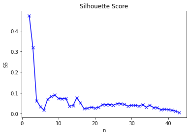

```python
import matplotlib.pyplot as plt
plt.plot(N, sos, 'bx-')
plt.xlabel('n')
plt.ylabel('SS')
plt.title('Silhouette Score')
plt.show()
```

The best silhouette score is the one close to 1. From the graph above the best will be 2, 3, and 9. We will omit 2 and 3 since it will be to general

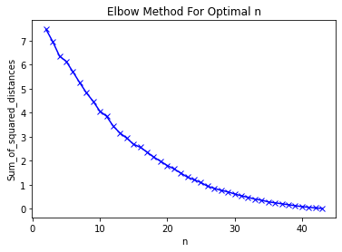

```python
import matplotlib.pyplot as plt
plt.plot(N, Sum_of_squared_distances, 'bx-')
plt.xlabel('n')
plt.ylabel('Sum_of_squared_distances')
plt.title('Elbow Method For Optimal n')
plt.show()
```

From Elbow method above it is not too obvious, but if we see closely we can see slope between from 9 to 10 which is something we are looking for.

Run *k*-means to cluster the neighborhood into 9 clusters.

```python
# set number of clusters
kclusters = 9

jakarta_grouped_clustering = jakarta_grouped.drop('Kecamatan', 1)

# run k-means clustering
kmeans = KMeans(n_clusters=kclusters, random_state=0).fit(jakarta_grouped_clustering)

# check cluster labels generated for each row in the dataframe
kmeans.labels_[0:10]
```

```
array([6, 0, 6, 6, 7, 3, 2, 6, 6, 6])
```

```python
#neighborhoods_venues_sorted = neighborhoods_venues_sorted.drop('Cluster Labels', 1)
#jakarta_merged=jakarta_merged.drop('Cluster Labels', 1)

# add clustering labels
neighborhoods_venues_sorted.insert(0, 'Cluster Labels', kmeans.labels_)


jakarta_merged = jakarta_data

# merge Toronto_grouped with Toronto_data to add latitude/longitude for each neighborhood
jakarta_merged = jakarta_merged.join(neighborhoods_venues_sorted.set_index('Kecamatan'), on='Kecamatan')

#df = df.join(df_geo.set_index('Postal Code'), on='PostalCode')

jakarta_merged.head(111) # check the last columns!
```

|  | Kabupaten | Kecamatan | Luas | Latitude | Longitude | Cluster Labels | 1st Most Common Venue | 2nd Most Common Venue | 3rd Most Common Venue |
| --- | --- | --- | --- | --- | --- | --- | --- | --- | --- |
| 0 | JAKARTA BARAT | CENGKARENG | 26.55 | -6.149093 | 106.734781 | 6 | Restaurant | Night Market | Movie Theater |
| 1 | JAKARTA BARAT | GROGOL PETAMBURAN | 9.99 | -6.164188 | 106.788317 | 6 | Noodle House | Asian Restaurant | Hotel |
| 2 | JAKARTA BARAT | KALI DERES | 30.23 | -6.134300 | 106.705800 | 6 | Noodle House | Supermarket | Indonesian Restaurant |
| 3 | JAKARTA BARAT | KEBON JERUK | 17.63 | -6.192572 | 106.769725 | 6 | Noodle House | Convenience Store | Indonesian Restaurant |
| 4 | JAKARTA BARAT | KEMBANGAN | 24.17 | -6.193000 | 106.742600 | 6 | Asian Restaurant | Seafood Restaurant | Bubble Tea Shop |
| 5 | JAKARTA BARAT | PALMERAH | 7.51 | -6.191002 | 106.794363 | 6 | Fast Food Restaurant | Pizza Place | Coffee Shop |
| 6 | JAKARTA BARAT | TAMAN SARI | 7.74 | -6.146142 | 106.818499 | 6 | Chinese Restaurant | Asian Restaurant | Noodle House |
| 7 | JAKARTA BARAT | TAMBORA | 5.40 | -6.146614 | 106.801046 | 6 | Convenience Store | Italian Restaurant | Fast Food Restaurant |
| 8 | JAKARTA PUSAT | CEMPAKA PUTIH | 4.70 | -6.181214 | 106.868548 | 0 | Pizza Place | BBQ Joint | Acehnese Restaurant |
| 9 | JAKARTA PUSAT | GAMBIR | 7.59 | -6.170300 | 106.814800 | 6 | Hotel | Indonesian Restaurant | Food Truck |
| 10 | JAKARTA PUSAT | JOHAR BARU | 2.37 | -6.183125 | 106.855332 | 1 | Convenience Store | Arcade | Indonesian Restaurant |
| 11 | JAKARTA PUSAT | KEMAYORAN | 7.25 | -6.162546 | 106.856890 | 6 | Hotel | Ice Cream Shop | Arcade |
| 12 | JAKARTA PUSAT | MENTENG | 6.53 | -6.195026 | 106.832224 | 6 | Indonesian Restaurant | Park | Coffee Shop |
| 13 | JAKARTA PUSAT | SAWAH BESAR | 6.16 | -6.155891 | 106.833580 | 6 | Convenience Store | Noodle House | Hotel |
| 14 | JAKARTA PUSAT | SENEN | 4.23 | -6.184971 | 106.843235 | 6 | Hotel | Indonesian Restaurant | Grocery Store |
| 15 | JAKARTA PUSAT | TANAH ABANG | 9.30 | -6.205258 | 106.809500 | 1 | Indonesian Restaurant | Seafood Restaurant | Coffee Shop |
| 16 | JAKARTA SELATAN | CILANDAK | 18.16 | -6.286898 | 106.794421 | 6 | Convenience Store | Gym | Indonesian Restaurant |
| 17 | JAKARTA SELATAN | JAGAKARSA | 24.88 | -6.330008 | 106.828191 | 1 | Indonesian Restaurant | Asian Restaurant | Soccer Stadium |
| 18 | JAKARTA SELATAN | KEBAYORAN BARU | 12.92 | -6.244146 | 106.800434 | 6 | Coffee Shop | Japanese Restaurant | Sushi Restaurant |
| 19 | JAKARTA SELATAN | KEBAYORAN LAMA | 16.74 | -6.243886 | 106.779859 | 6 | Steakhouse | Coffee Shop | Japanese Restaurant |
| 20 | JAKARTA SELATAN | MAMPANG PRAPATAN | 7.74 | -6.249374 | 106.821860 | 4 | Fast Food Restaurant | Indonesian Restaurant | Noodle House |
| 21 | JAKARTA SELATAN | PANCORAN | 8.53 | -6.253298 | 106.844977 | 1 | Indonesian Restaurant | Asian Restaurant | Food Stand |
| 22 | JAKARTA SELATAN | PASAR MINGGU | 21.71 | -6.285642 | 106.829735 | 6 | Convenience Store | Japanese Restaurant | Breakfast Spot |
| 23 | JAKARTA SELATAN | PESANGGRAHAN | 13.46 | -6.248830 | 106.759631 | 4 | Noodle House | Food Truck | Indonesian Restaurant |
| 24 | JAKARTA SELATAN | SETIA BUDI | 8.86 | -6.219600 | 106.832600 | 6 | Coffee Shop | Hotel | Café |
| 25 | JAKARTA SELATAN | TEBET | 9.03 | -6.226016 | 106.858396 | 6 | Indonesian Restaurant | Asian Restaurant | Convenience Store |
| 26 | JAKARTA TIMUR | CAKUNG | 42.27 | -6.185562 | 106.940109 | 6 | Lounge | Gas Station | Neighborhood |
| 27 | JAKARTA TIMUR | CIPAYUNG | 28.46 | -6.329399 | 106.903739 | 3 | Shop & Service | Restaurant | Wine Bar |
| 28 | JAKARTA TIMUR | CIRACAS | 16.08 | -6.329635 | 106.876604 | 2 | Playground | Department Store | Dog Run |
| 29 | JAKARTA TIMUR | DUREN SAWIT | 22.66 | -6.234138 | 106.919247 | 6 | Indonesian Meatball Place | Convenience Store | Mediterranean Restaurant |
| 30 | JAKARTA TIMUR | JATINEGARA | 10.26 | -6.214976 | 106.870340 | 6 | Jewelry Store | Asian Restaurant | Donut Shop |
| 31 | JAKARTA TIMUR | KRAMAT JATI | 13.30 | -6.275477 | 106.870376 | 6 | Hospital | Chinese Restaurant | Seafood Restaurant |
| 32 | JAKARTA TIMUR | MAKASAR | 21.86 | -6.269341 | 106.888818 | 1 | Indonesian Restaurant | Airport Lounge | Asian Restaurant |
| 33 | JAKARTA TIMUR | MATRAMAN | 4.88 | -6.203624 | 106.864579 | 0 | Pizza Place | Dog Run | College Cafeteria |
| 34 | JAKARTA TIMUR | PASAR REBO | 12.97 | -6.324973 | 106.853376 | 4 | Cosmetics Shop | Indonesian Restaurant | Bakery |
| 35 | JAKARTA TIMUR | PULO GADUNG | 15.60 | -6.191109 | 106.890605 | 6 | Indonesian Restaurant | Convenience Store | Athletics & Sports |
| 36 | JAKARTA UTARA | CILINCING | 37.70 | -6.129015 | 106.944454 | 7 | Park | Shopping Mall | Wine Bar |
| 37 | JAKARTA UTARA | KELAPA GADING | 16.12 | -6.159938 | 106.902483 | 1 | Indonesian Restaurant | Asian Restaurant | Steakhouse |
| 38 | JAKARTA UTARA | KOJA | 13.21 | -6.120750 | 106.907362 | 0 | Pizza Place | Indonesian Restaurant | Bookstore |
| 39 | JAKARTA UTARA | PADEMANGAN | 9.91 | -6.129052 | 106.828972 | 6 | Hotel | Seafood Restaurant | Asian Restaurant |
| 40 | JAKARTA UTARA | PENJARINGAN | 34.48 | -6.117265 | 106.767433 | 6 | Pharmacy | Boutique | Spa |
| 41 | JAKARTA UTARA | TANJUNG PRIOK | 25.12 | -6.128858 | 106.870793 | 1 | Convenience Store | Asian Restaurant | Cosmetics Shop |
| 42 | KABUPATEN ADMINITRATIF KEPULAUAN SERIBU | KEPULAUAN SERIBU SELATAN | 3.05 | -5.803887 | 106.525306 | 8 | Boat or Ferry | Clothing Store | Dumpling Restaurant |
| 43 | KABUPATEN ADMINITRATIF KEPULAUAN SERIBU | KEPULAUAN SERIBU UTARA | 5.65 | -5.654443 | 106.568084 | 5 | Resort | Wine Bar | Dog Run |

Finally, let's visualize the resulting clusters

```python
# create map
map_clusters = folium.Map(location=[latitude, longitude], zoom_start=11)

# set color scheme for the clusters
x = np.arange(kclusters)
ys = [i + x + (i*x)**2 for i in range(kclusters)]
colors_array = cm.rainbow(np.linspace(0, 1, len(ys)))
rainbow = [colors.rgb2hex(i) for i in colors_array]

# add markers to the map
markers_colors = []
for lat, lon, poi, cluster in zip(jakarta_merged['Latitude'], jakarta_merged['Longitude'], jakarta_merged['Kecamatan'], jakarta_merged['Cluster Labels']):
    label = folium.Popup(str(poi) + ' Cluster ' + str(cluster), parse_html=True)
    folium.CircleMarker(
        [lat, lon],
        radius=5,
        popup=label,
        color=rainbow[cluster-1],
        fill=True,
        fill_color=rainbow[cluster-1],
        fill_opacity=0.7).add_to(map_clusters)

map_clusters
```

Make this Notebook Trusted to load map: File -> Trust Notebook

[interactive chart not shown]

## 5. Examine Clusters

Now, we examine each cluster and determine the discriminating venue categories that distinguish each cluster. Based on the defining categories, we can then assign a name to each cluster.

#### Cluster 1. Pizza Place

In this Cluster we find there are alot of Pizza Place in this Kecamatan

```python
jakarta_merged.loc[jakarta_merged['Cluster Labels'] == 0, jakarta_merged.columns[[1] + list(range(5, jakarta_merged.shape[1]))]]
```

|  | Kecamatan | Cluster Labels | 1st Most Common Venue | 2nd Most Common Venue | 3rd Most Common Venue |
| --- | --- | --- | --- | --- | --- |
| 8 | CEMPAKA PUTIH | 0 | Pizza Place | BBQ Joint | Acehnese Restaurant |
| 33 | MATRAMAN | 0 | Pizza Place | Dog Run | College Cafeteria |
| 38 | KOJA | 0 | Pizza Place | Indonesian Restaurant | Bookstore |

#### Cluster 2. Indonesian Restaurant and Asian Restaurant

```python
jakarta_merged.loc[jakarta_merged['Cluster Labels'] == 1, jakarta_merged.columns[[1] + list(range(5, jakarta_merged.shape[1]))]]
```

|  | Kecamatan | Cluster Labels | 1st Most Common Venue | 2nd Most Common Venue | 3rd Most Common Venue |
| --- | --- | --- | --- | --- | --- |
| 10 | JOHAR BARU | 1 | Convenience Store | Arcade | Indonesian Restaurant |
| 15 | TANAH ABANG | 1 | Indonesian Restaurant | Seafood Restaurant | Coffee Shop |
| 17 | JAGAKARSA | 1 | Indonesian Restaurant | Asian Restaurant | Soccer Stadium |
| 21 | PANCORAN | 1 | Indonesian Restaurant | Asian Restaurant | Food Stand |
| 32 | MAKASAR | 1 | Indonesian Restaurant | Airport Lounge | Asian Restaurant |
| 37 | KELAPA GADING | 1 | Indonesian Restaurant | Asian Restaurant | Steakhouse |
| 41 | TANJUNG PRIOK | 1 | Convenience Store | Asian Restaurant | Cosmetics Shop |

#### Cluster 3. Playground

It only one Kecamatan that has Playground

```python
jakarta_merged.loc[jakarta_merged['Cluster Labels'] == 2, jakarta_merged.columns[[1] + list(range(5, jakarta_merged.shape[1]))]]
```

|  | Kecamatan | Cluster Labels | 1st Most Common Venue | 2nd Most Common Venue | 3rd Most Common Venue |
| --- | --- | --- | --- | --- | --- |
| 28 | CIRACAS | 2 | Playground | Department Store | Dog Run |

#### Cluster 4. Shop and Service

This Kecamatan famous for service store and workshop

```python
jakarta_merged.loc[jakarta_merged['Cluster Labels'] == 3, jakarta_merged.columns[[1] + list(range(5, jakarta_merged.shape[1]))]]
```

|  | Kecamatan | Cluster Labels | 1st Most Common Venue | 2nd Most Common Venue | 3rd Most Common Venue |
| --- | --- | --- | --- | --- | --- |
| 27 | CIPAYUNG | 3 | Shop & Service | Restaurant | Wine Bar |

#### Cluster 5. Fast Food and Cosmetic Shop

```python
jakarta_merged.loc[jakarta_merged['Cluster Labels'] == 4, jakarta_merged.columns[[1] + list(range(5, jakarta_merged.shape[1]))]]
```

|  | Kecamatan | Cluster Labels | 1st Most Common Venue | 2nd Most Common Venue | 3rd Most Common Venue |
| --- | --- | --- | --- | --- | --- |
| 20 | MAMPANG PRAPATAN | 4 | Fast Food Restaurant | Indonesian Restaurant | Noodle House |
| 23 | PESANGGRAHAN | 4 | Noodle House | Food Truck | Indonesian Restaurant |
| 34 | PASAR REBO | 4 | Cosmetics Shop | Indonesian Restaurant | Bakery |

#### Cluster 6. Resort

This area very famous for vacation and leasure, it has lots of Resort since it is an Island. Similar with Cluster 9

```python
jakarta_merged.loc[jakarta_merged['Cluster Labels'] == 5, jakarta_merged.columns[[1] + list(range(5, jakarta_merged.shape[1]))]]
```

|  | Kecamatan | Cluster Labels | 1st Most Common Venue | 2nd Most Common Venue | 3rd Most Common Venue |
| --- | --- | --- | --- | --- | --- |
| 43 | KEPULAUAN SERIBU UTARA | 5 | Resort | Wine Bar | Dog Run |

#### Cluster 7. Noodle House, Chinese Restaurant and Hotel

It seems there is alot of Noodle House and Restaurant and i proves that these Kecamatan are very lively

```python
jakarta_merged.loc[jakarta_merged['Cluster Labels'] == 6, jakarta_merged.columns[[1] + list(range(5, jakarta_merged.shape[1]))]]
```

|  | Kecamatan | Cluster Labels | 1st Most Common Venue | 2nd Most Common Venue | 3rd Most Common Venue |
| --- | --- | --- | --- | --- | --- |
| 0 | CENGKARENG | 6 | Restaurant | Night Market | Movie Theater |
| 1 | GROGOL PETAMBURAN | 6 | Noodle House | Asian Restaurant | Hotel |
| 2 | KALI DERES | 6 | Noodle House | Supermarket | Indonesian Restaurant |
| 3 | KEBON JERUK | 6 | Noodle House | Convenience Store | Indonesian Restaurant |
| 4 | KEMBANGAN | 6 | Asian Restaurant | Seafood Restaurant | Bubble Tea Shop |
| 5 | PALMERAH | 6 | Fast Food Restaurant | Pizza Place | Coffee Shop |
| 6 | TAMAN SARI | 6 | Chinese Restaurant | Asian Restaurant | Noodle House |
| 7 | TAMBORA | 6 | Convenience Store | Italian Restaurant | Fast Food Restaurant |
| 9 | GAMBIR | 6 | Hotel | Indonesian Restaurant | Food Truck |
| 11 | KEMAYORAN | 6 | Hotel | Ice Cream Shop | Arcade |
| 12 | MENTENG | 6 | Indonesian Restaurant | Park | Coffee Shop |
| 13 | SAWAH BESAR | 6 | Convenience Store | Noodle House | Hotel |
| 14 | SENEN | 6 | Hotel | Indonesian Restaurant | Grocery Store |
| 16 | CILANDAK | 6 | Convenience Store | Gym | Indonesian Restaurant |
| 18 | KEBAYORAN BARU | 6 | Coffee Shop | Japanese Restaurant | Sushi Restaurant |
| 19 | KEBAYORAN LAMA | 6 | Steakhouse | Coffee Shop | Japanese Restaurant |
| 22 | PASAR MINGGU | 6 | Convenience Store | Japanese Restaurant | Breakfast Spot |
| 24 | SETIA BUDI | 6 | Coffee Shop | Hotel | Café |
| 25 | TEBET | 6 | Indonesian Restaurant | Asian Restaurant | Convenience Store |
| 26 | CAKUNG | 6 | Lounge | Gas Station | Neighborhood |
| 29 | DUREN SAWIT | 6 | Indonesian Meatball Place | Convenience Store | Mediterranean Restaurant |
| 30 | JATINEGARA | 6 | Jewelry Store | Asian Restaurant | Donut Shop |
| 31 | KRAMAT JATI | 6 | Hospital | Chinese Restaurant | Seafood Restaurant |
| 35 | PULO GADUNG | 6 | Indonesian Restaurant | Convenience Store | Athletics & Sports |
| 39 | PADEMANGAN | 6 | Hotel | Seafood Restaurant | Asian Restaurant |
| 40 | PENJARINGAN | 6 | Pharmacy | Boutique | Spa |

#### Cluster 8. Park

Actually this area is an Industrial area, that is why being clustered specifically.

```python
jakarta_merged.loc[jakarta_merged['Cluster Labels'] == 7, jakarta_merged.columns[[1] + list(range(5, jakarta_merged.shape[1]))]]
```

|  | Kecamatan | Cluster Labels | 1st Most Common Venue | 2nd Most Common Venue | 3rd Most Common Venue |
| --- | --- | --- | --- | --- | --- |
| 36 | CILINCING | 7 | Park | Shopping Mall | Wine Bar |

#### Cluster 9. Boat and Fery

This area very famous for vacation and leasure. Similar with Cluster 6

```python
jakarta_merged.loc[jakarta_merged['Cluster Labels'] == 8, jakarta_merged.columns[[1] + list(range(5, jakarta_merged.shape[1]))]]
```

|  | Kecamatan | Cluster Labels | 1st Most Common Venue | 2nd Most Common Venue | 3rd Most Common Venue |
| --- | --- | --- | --- | --- | --- |
| 42 | KEPULAUAN SERIBU SELATAN | 8 | Boat or Ferry | Clothing Store | Dumpling Restaurant |

### Result and Conclusion

From above 9 specific clusters we can determine each neighborhood segmentation and specific economical business potential that can be done specifically. This can be used by investor to invest and build business for each of neighborhood in Jakarta, it can be from Restaurant or Hotel, Resort, or even Workshop :)

END